# code-for-aml-xgboost

```python
#importing necessary libraries
import os

import pandas as pd
from pandas import DataFrame
from pandas import concat
import numpy as np
from numpy import concatenate
from math import sqrt

import matplotlib.pyplot as plt
import plotly.express as px
import seaborn as sns
from collections import Counter

from sklearn.preprocessing import MinMaxScaler, StandardScaler
from sklearn.metrics import mean_squared_error,mean_absolute_error,r2_score
from sklearn.model_selection import train_test_split
from sklearn.linear_model import LinearRegression
from sklearn.metrics import mean_squared_error
from sklearn.model_selection import train_test_split
from sklearn.decomposition import PCA
from sklearn.preprocessing import OneHotEncoder
from sklearn.preprocessing import LabelEncoder
from category_encoders import CountEncoder, TargetEncoder
from scipy.sparse import hstack

import torch
import torch.nn as nn
from torch.utils.data import Dataset, DataLoader
```

```python
!pip install category_encoders
```

```python
#importing the dataset
df = pd.read_csv("/content/HI-Small_Trans.csv")
print(df.columns);
print(df.shape)
df.head()
```

```
Index(['Timestamp', 'From Bank', 'Account', 'To Bank', 'Account.1',
       'Amount Received', 'Receiving Currency', 'Amount Paid',
       'Payment Currency', 'Payment Format', 'Is Laundering'],
      dtype='object')
(5078345, 11)
```

|  | Timestamp | From Bank | Account | To Bank | Account.1 | Amount Received | Receiving Currency | Amount Paid | Payment Currency | Payment Format | Is Laundering |
| --- | --- | --- | --- | --- | --- | --- | --- | --- | --- | --- | --- |
| 0 | 2022/09/01 00:20 | 10 | 8000EBD30 | 10 | 8000EBD30 | 3697.34 | US Dollar | 3697.34 | US Dollar | Reinvestment | 0 |
| 1 | 2022/09/01 00:20 | 3208 | 8000F4580 | 1 | 8000F5340 | 0.01 | US Dollar | 0.01 | US Dollar | Cheque | 0 |
| 2 | 2022/09/01 00:00 | 3209 | 8000F4670 | 3209 | 8000F4670 | 14675.57 | US Dollar | 14675.57 | US Dollar | Reinvestment | 0 |
| 3 | 2022/09/01 00:02 | 12 | 8000F5030 | 12 | 8000F5030 | 2806.97 | US Dollar | 2806.97 | US Dollar | Reinvestment | 0 |
| 4 | 2022/09/01 00:06 | 10 | 8000F5200 | 10 | 8000F5200 | 36682.97 | US Dollar | 36682.97 | US Dollar | Reinvestment | 0 |

```python
df = df.rename(columns={'Is Laundering': 'Is_Laundering'})
```

```python
df[-5:]
```

|  | Timestamp | From Bank | Account | To Bank | Account.1 | Amount Received | Receiving Currency | Amount Paid | Payment Currency | Payment Format | Is_Laundering |
| --- | --- | --- | --- | --- | --- | --- | --- | --- | --- | --- | --- |
| 5078340 | 2022/09/10 23:57 | 54219 | 8148A6631 | 256398 | 8148A8711 | 0.154978 | Bitcoin | 0.154978 | Bitcoin | Bitcoin | 0 |
| 5078341 | 2022/09/10 23:35 | 15 | 8148A8671 | 256398 | 8148A8711 | 0.108128 | Bitcoin | 0.108128 | Bitcoin | Bitcoin | 0 |
| 5078342 | 2022/09/10 23:52 | 154365 | 8148A6771 | 256398 | 8148A8711 | 0.004988 | Bitcoin | 0.004988 | Bitcoin | Bitcoin | 0 |
| 5078343 | 2022/09/10 23:46 | 256398 | 8148A6311 | 256398 | 8148A8711 | 0.038417 | Bitcoin | 0.038417 | Bitcoin | Bitcoin | 0 |
| 5078344 | 2022/09/10 23:37 | 154518 | 8148A6091 | 256398 | 8148A8711 | 0.281983 | Bitcoin | 0.281983 | Bitcoin | Bitcoin | 0 |

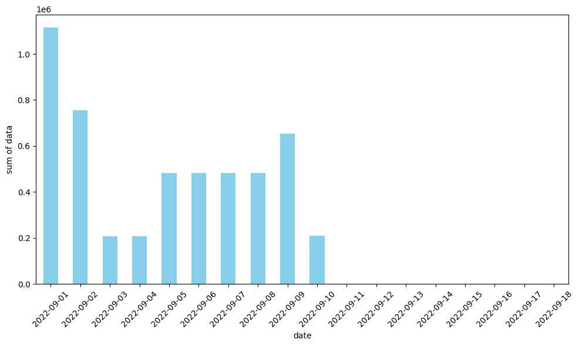

```python
# View the data distribution at the granularity of dates
df['Timestamp'] = pd.to_datetime(df['Timestamp'])

df['Date'] = df['Timestamp'].dt.date
df.set_index('Date', inplace=True)

daily_data_count = df.groupby(df.index).size()

plt.figure(figsize=(10, 6))
daily_data_count.plot(kind='bar', color='skyblue')
plt.xlabel('date')
plt.ylabel('sum of data')
plt.xticks(rotation=45)
plt.tight_layout()

plt.show()
```

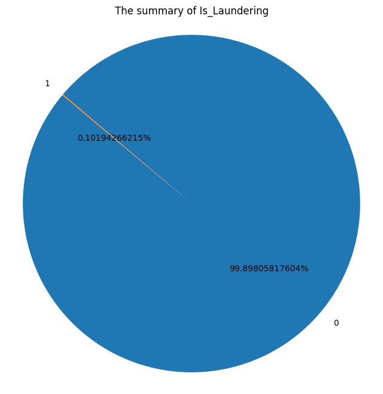

```python
# Analyze the distribution of the "Is_Laundering" column
laundering_counts = df['Is_Laundering'].value_counts()

plt.figure(figsize=(8, 8))
plt.pie(laundering_counts, labels=laundering_counts.index, autopct='%1.11f%%', startangle=140)
plt.title('The summary of Is_Laundering')
plt.axis('equal')

plt.show()
```

It can be seen that the distribution of labels is imbalanced.

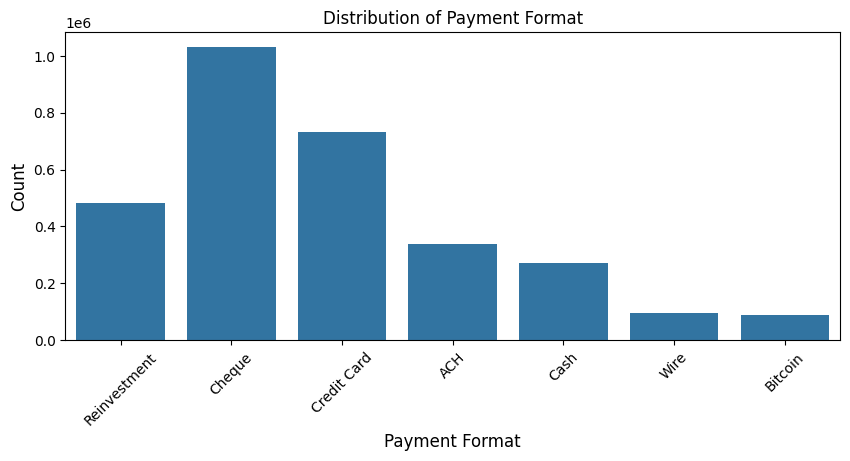

```python
# View the distribution of Payment Format
f, ax = plt.subplots(figsize=(10,4))

sns.countplot(x='Payment Format', data=df, ax=ax)
ax.set_title('Distribution of Payment Format')
ax.set_xlabel('Payment Format', fontsize=12)
ax.set_ylabel('Count', fontsize=12)
ax.tick_params(axis='x', labelrotation=45) # rotate x-axis labels

# Set the x-axis tick labels to the original values
# ax.set_xticklabels(df['Payment Format'].unique())

plt.show()
```

```python
df['Payment Format'].unique()
```

```
array(['Reinvestment', 'Cheque', 'Credit Card', 'ACH', 'Cash', 'Wire',
       'Bitcoin'], dtype=object)
```

The complexity of these payment methods, from least to most complex, is as follows:

- **Cash**: Cash does not require any systems or devices and allows direct payment, making it the simplest method.
- **Cheque**: Cheques only require a paper check and a bank account. While simple, they involve a waiting period for settlement.
- **Automated Clearing House (ACH)**: ACH requires the establishment of interbank transfer systems, which involve multiple steps but are simple for everyday use.
- **Credit Card**: Credit cards appear simple but involve handling complex systems for card issuer settlements and other processes.
- **Wire Transfer**: Wire transfers seem like direct transactions but involve complex international regulations and settlement procedures.
- **Bitcoin**: Bitcoin is abstract in concept and requires managing keys, transactions, and other new concepts.
- **Reinvestment**: (No further context provided about this method.)

```python
df.info()
```

[output not shown]

It can be seen that some attributes are of type object, so they need to be quantified later.

```python
# Remove duplicate data
print(df.shape)  # Print the original shape of the DataFrame
df = df.drop_duplicates(keep='first')  # Drop duplicate rows, keeping the first occurrence
print(df.shape)  # Print the shape of the DataFrame after removing duplicates
```

```
(3042692, 11)
```

```
(3042690, 11)
```

```python
# Check for the presence of NA (missing values)
has_nan = df.isnull().values.any()

if has_nan:
    print("NaN")  # Print "NaN" if there are missing values
    print(df.isnull().sum())  # Display the count of missing values in each column
else:
    print("not NaN")  # Print "not NaN" if there are no missing values
```

```
not NaN
```

```python
# Basic information about the data
df.describe()
```

|  | Timestamp | From Bank | To Bank | Amount Received | Amount Paid | Is_Laundering |
| --- | --- | --- | --- | --- | --- | --- |
| count | 3042690 | 3.042690e+06 | 3.042690e+06 | 3.042690e+06 | 3.042690e+06 | 3.042690e+06 |
| mean | 2022-09-03 02:18:15.814992384 | 4.835682e+04 | 6.664992e+04 | 6.391440e+06 | 4.769082e+06 | 9.412724e-04 |
| min | 2022-09-01 00:00:00 | 1.000000e+00 | 1.000000e+00 | 1.000000e-06 | 1.000000e-06 | 0.000000e+00 |
| 25% | 2022-09-01 13:26:00 | 2.110000e+02 | 4.503000e+03 | 1.717100e+02 | 1.727900e+02 | 0.000000e+00 |
| 50% | 2022-09-02 12:41:00 | 1.129600e+04 | 2.161100e+04 | 1.525560e+03 | 1.529800e+03 | 0.000000e+00 |
| 75% | 2022-09-04 23:43:00 | 3.109300e+04 | 1.224630e+05 | 1.445814e+04 | 1.440550e+04 | 0.000000e+00 |
| max | 2022-09-14 17:40:00 | 3.563030e+05 | 3.562940e+05 | 6.260355e+11 | 6.260355e+11 | 1.000000e+00 |
| std | NaN | 8.389061e+04 | 8.538819e+04 | 8.937149e+08 | 6.496889e+08 | 3.066572e-02 |

```python
# Select columns of type 'object'
object_cols = df.select_dtypes(include=['object']).columns.tolist()
object_cols
```

```
['Account',
 'Account.1',
 'Receiving Currency',
 'Payment Currency',
 'Payment Format']
```

```python
df.head()
```

| Date | Timestamp | From Bank | Account | To Bank | Account.1 | Amount Received | Receiving Currency | Amount Paid | Payment Currency | Payment Format | Is_Laundering |
| --- | --- | --- | --- | --- | --- | --- | --- | --- | --- | --- | --- |
| 2022-09-01 | 2022-09-01 00:20:00 | 10 | 8000EBD30 | 10 | 8000EBD30 | 3697.34 | US Dollar | 3697.34 | US Dollar | Reinvestment | 0 |
| 2022-09-01 | 2022-09-01 00:20:00 | 3208 | 8000F4580 | 1 | 8000F5340 | 0.01 | US Dollar | 0.01 | US Dollar | Cheque | 0 |
| 2022-09-01 | 2022-09-01 00:00:00 | 3209 | 8000F4670 | 3209 | 8000F4670 | 14675.57 | US Dollar | 14675.57 | US Dollar | Reinvestment | 0 |
| 2022-09-01 | 2022-09-01 00:02:00 | 12 | 8000F5030 | 12 | 8000F5030 | 2806.97 | US Dollar | 2806.97 | US Dollar | Reinvestment | 0 |
| 2022-09-01 | 2022-09-01 00:06:00 | 10 | 8000F5200 | 10 | 8000F5200 | 36682.97 | US Dollar | 36682.97 | US Dollar | Reinvestment | 0 |

```python
# Display the number of unique values for each attribute and the distribution of its value counts
for col in object_cols:
    print(col, '\n')
    print(df[col].nunique(), '\n')
    print(df[col].value_counts())
```

```
Account

492814

Account
100428660    93343
1004286A8    57134
100428978    11258
1004286F0    10319
100428780     9510
             ...
813046020        1
809CCD140        1
81237F620        1
8123805E0        1
8012F11A0        1
Name: count, Length: 492814, dtype: int64
Account.1

419670

Account.1
100428660    545
1004286A8    328
8051A3FA0     93
8018859B0     86
80B847A90     85
            ...
8015C6290      1
80CE8E060      1
807F156D0      1
81477F1C1      1
804E2DE30      1
Name: count, Length: 419670, dtype: int64
Receiving Currency

15

Receiving Currency
US Dollar            1127929
```

[output cut: 34 more lines]

```
Brazil Real            42097
Name: count, dtype: int64
Payment Format

7

Payment Format
Cheque          1032135
Credit Card      733924
Reinvestment     481056
ACH              339065
Cash             272943
Wire              96754
Bitcoin           86813
Name: count, dtype: int64
```

```python
# Select object type columns
object_cols = df.select_dtypes(include=['object']).columns.tolist()
print(object_cols)

# Use Label Encoding to quantify object type columns
label_encoder = LabelEncoder()
for col in object_cols:
    if col != 'Payment Format':
        df[col] = label_encoder.fit_transform(df[col])

# Sort by the complexity of payment methods
payment_map = {'Cash': 1, 'Cheque': 2, 'ACH': 3, 'Credit Card': 4, 'Wire': 5, 'Bitcoin': 6, 'Reinvestment': 7}

# Use map method to encode Payment Format column
df['Payment Format'] = df['Payment Format'].map(payment_map)

# Output the processed data
df.head()
```

```
['Account', 'Account.1', 'Receiving Currency', 'Payment Currency', 'Payment Format']
```

| Date | Timestamp | From Bank | Account | To Bank | Account.1 | Amount Received | Receiving Currency | Amount Paid | Payment Currency | Payment Format | Is_Laundering |
| --- | --- | --- | --- | --- | --- | --- | --- | --- | --- | --- | --- |
| 2022-09-01 | 2022-09-01 00:20:00 | 10 | 941 | 10 | 896 | 3697.34 | 12 | 3697.34 | 12 | 7 | 0 |
| 2022-09-01 | 2022-09-01 00:20:00 | 3208 | 989 | 1 | 945 | 0.01 | 12 | 0.01 | 12 | 2 | 0 |
| 2022-09-01 | 2022-09-01 00:00:00 | 3209 | 990 | 3209 | 936 | 14675.57 | 12 | 14675.57 | 12 | 7 | 0 |
| 2022-09-01 | 2022-09-01 00:02:00 | 12 | 996 | 12 | 941 | 2806.97 | 12 | 2806.97 | 12 | 7 | 0 |
| 2022-09-01 | 2022-09-01 00:06:00 | 10 | 998 | 10 | 943 | 36682.97 | 12 | 36682.97 | 12 | 7 | 0 |

**归一化：**

```python
# Normalize all attributes

# Separate labels from the dataset
labels = df['Is_Laundering']
df = df.drop('Is_Laundering', axis=1)

# Convert the 'Timestamp' column to a Unix timestamp
'''
    This line converts the `Timestamp` column in the `df` DataFrame to Unix timestamp.
    Specifically, it converts the date-time values in the `Timestamp` column to `Timestamp` objects from Pandas.
    Then, it converts these `Timestamp` objects to integers representing nanoseconds since January 1, 1970.
    Finally, it divides by 10**9 to convert nanoseconds to seconds.
'''
df['Timestamp'] = pd.to_datetime(df['Timestamp']).astype(int) / 10**9

# Normalize the dataset
scaler = MinMaxScaler(feature_range=(-1, 1))
scaler.fit(df)
df_normalized = scaler.transform(df)

# Convert the normalized data back to a DataFrame and set column names
df_normalized = pd.DataFrame(df_normalized, columns=df.columns)

# Add the label column back to the normalized dataset
df_normalized['Is_Laundering'] = labels.tolist()

# Output the normalized data
print(df_normalized.head())
```

```
   Timestamp  From Bank   Account   To Bank  Account.1  Amount Received  \
0  -0.997978  -0.999949 -0.996181 -0.999949  -0.995730             -1.0
1  -0.997978  -0.981998 -0.995986 -1.000000  -0.995496             -1.0
2  -1.000000  -0.981993 -0.995982 -0.981992  -0.995539             -1.0
3  -0.999798  -0.999938 -0.995958 -0.999938  -0.995516             -1.0
4  -0.999393  -0.999949 -0.995950 -0.999949  -0.995506             -1.0

   Receiving Currency  Amount Paid  Payment Currency  Payment Format  \
0            0.714286         -1.0          0.714286        1.000000
1            0.714286         -1.0          0.714286       -0.666667
2            0.714286         -1.0          0.714286        1.000000
3            0.714286         -1.0          0.714286        1.000000
4            0.714286         -1.0          0.714286        1.000000

   Is_Laundering
0              0
1              0
2              0
3              0
4              0
```

```python
# Select rows where 'Is_Laundering' column is 1
df_laundering = df_normalized.loc[df_normalized['Is_Laundering'] == 1]

# Output the count of rows in the normalized dataset
print(df_normalized.count())

# Output the count of rows for the selected subset
df_laundering.count()
```

```
Timestamp             3042690
From Bank             3042690
Account               3042690
To Bank               3042690
Account.1             3042690
Amount Received       3042690
Receiving Currency    3042690
Amount Paid           3042690
Payment Currency      3042690
Payment Format        3042690
Is_Laundering         3042690
dtype: int64
```

|  | 0 |
| --- | --- |
| Timestamp | 2864 |
| From Bank | 2864 |
| Account | 2864 |
| To Bank | 2864 |
| Account.1 | 2864 |
| Amount Received | 2864 |
| Receiving Currency | 2864 |
| Amount Paid | 2864 |
| Payment Currency | 2864 |
| Payment Format | 2864 |
| Is_Laundering | 2864 |

**dtype:** int64

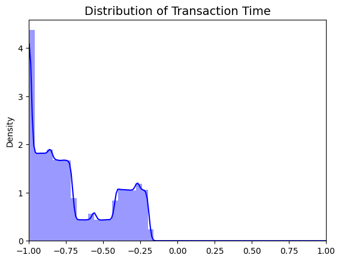

```python
time_val = df_normalized['Timestamp'].values
sns.distplot(time_val, color='b')
plt.title('Distribution of Transaction Time', fontsize=14)
plt.xlim([min(time_val), max(time_val)])

plt.show()
```

Next, split the dataset into training and testing sets

```python
from sklearn.model_selection import KFold, StratifiedKFold

X = df_normalized.drop('Is_Laundering', axis=1)
y = df_normalized['Is_Laundering']

sss = StratifiedKFold(n_splits=5, random_state=None, shuffle=False)

for train_index, test_index in sss.split(X, y):
    print("Train:", train_index, "Test:", test_index)
    original_Xtrain, original_Xtest = X.iloc[train_index], X.iloc[test_index]
    original_ytrain, original_ytest = y.iloc[train_index], y.iloc[test_index]

    # We already have X_train and y_train for undersample data thats why I am using original to distinguish and to not overwrite these variables.
    # original_Xtrain, original_Xtest, original_ytrain, original_ytest = train_test_split(X, y, test_size=0.2, random_state=42)

    # Check the Distribution of the labels


    # Turn into an array
    original_Xtrain = original_Xtrain.values
    original_Xtest = original_Xtest.values
    original_ytrain = original_ytrain.values
    original_ytest = original_ytest.values

    # See if both the train and test label distribution are similarly distributed
    train_unique_label, train_counts_label = np.unique(original_ytrain, return_counts=True)
    test_unique_label, test_counts_label = np.unique(original_ytest, return_counts=True)
    print('-' * 100)

    print('Label Distributions: \n')
    print(train_counts_label/ len(original_ytrain))
    print(test_counts_label/ len(original_ytest))
```

```
Train: [ 608277  608278  608279 ... 3042687 3042688 3042689] Test: [     0      1      2 ... 963545 972607 987139]
----------------------------------------------------------------------------------------------------
Label Distributions:

[9.99058399e-01 9.41601018e-04]
[9.99060042e-01 9.39957735e-04]
Train: [      0       1       2 ... 3042687 3042688 3042689] Test: [ 608277  608278  608279 ... 1839128 1839130 1839407]
----------------------------------------------------------------------------------------------------
Label Distributions:

[9.99058810e-01 9.41190197e-04]
[9.99058399e-01 9.41601018e-04]
Train: [      0       1       2 ... 3042687 3042688 3042689] Test: [1216647 1216648 1216649 ... 2132662 2132663 2132664]
----------------------------------------------------------------------------------------------------
Label Distributions:

[9.99058810e-01 9.41190197e-04]
[9.99058399e-01 9.41601018e-04]
Train: [      0       1       2 ... 3042687 3042688 3042689] Test: [1825013 1825014 1825015 ... 2450238 2450871 2455319]
----------------------------------------------------------------------------------------------------
Label Distributions:

[9.99058810e-01 9.41190197e-04]
[9.99058399e-01 9.41601018e-04]
Train: [      0       1       2 ... 2450238 2450871 2455319] Test: [2434147 2434148 2434149 ... 3042687 3042688 3042689]
----------------------------------------------------------------------------------------------------
Label Distributions:

[9.99058810e-01 9.41190197e-04]
[9.99058399e-01 9.41601018e-04]
```

It can be seen that the data has been split into training and testing sets, and the distribution is balanced.

Next, prepare the data using the undersampling method:

```python
# Since our classes are highly skewed we should make them equivalent in order to have a normal distribution of the classes.

# Lets shuffle the data before creating the subsamples

df_normalized = df_normalized.sample(frac=1)

# amount of fraud classes 492 rows.
fraud_df = df_normalized.loc[df_normalized['Is_Laundering'] == 1]
non_fraud_df = df_normalized.loc[df_normalized['Is_Laundering'] == 0][:len(fraud_df)]

normal_distributed_df = pd.concat([fraud_df, non_fraud_df])

# Shuffle dataframe rows
new_df = normal_distributed_df.sample(frac=1, random_state=42)

new_df.head()
```

|  | Timestamp | From Bank | Account | To Bank | Account.1 | Amount Received | Receiving Currency | Amount Paid | Payment Currency | Payment Format | Is_Laundering |
| --- | --- | --- | --- | --- | --- | --- | --- | --- | --- | --- | --- |
| 2183598 | -0.494540 | -0.998827 | -0.186811 | -0.295108 | -0.080056 | -1.0 | -0.571429 | -1.0 | -0.571429 | -0.333333 | 0 |
| 2937334 | -0.226390 | -0.998821 | 0.271639 | -0.999388 | 0.262285 | -1.0 | -0.714286 | -1.0 | -0.714286 | 0.000000 | 0 |
| 1630950 | -0.755106 | -0.872260 | -0.835934 | -0.999938 | -0.788610 | -1.0 | -0.428571 | -1.0 | -0.428571 | 0.000000 | 0 |
| 617751 | -0.942669 | -0.909582 | -0.605769 | 0.235399 | 0.742230 | -1.0 | 0.714286 | -1.0 | 0.714286 | -1.000000 | 0 |
| 2699362 | -0.296158 | -0.998759 | 0.741021 | -0.167045 | 0.749183 | -1.0 | 0.142857 | -1.0 | 0.142857 | -0.666667 | 0 |

```
Distribution of the Is_Launderinges in the subsample dataset
Is_Laundering
0    0.5
1    0.5
Name: count, dtype: float64
```

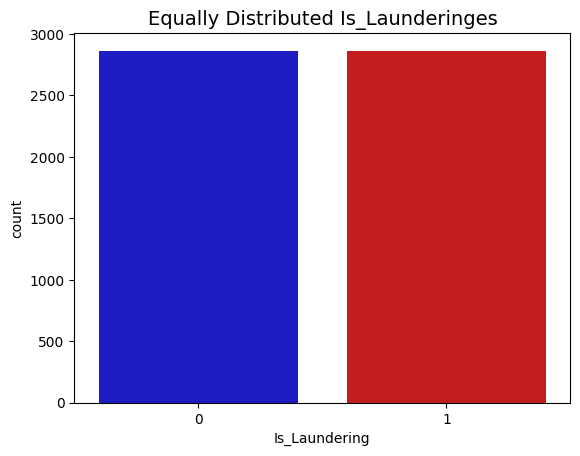

```python
print('Distribution of the Is_Launderinges in the subsample dataset')
print(new_df['Is_Laundering'].value_counts()/len(new_df))

colors = ["#0101DF", "#DF0101"]
sns.countplot(data=new_df, x='Is_Laundering', palette=colors)
plt.title('Equally Distributed Is_Launderinges', fontsize=14)
plt.show()
```

****Correlation Coefficients:****

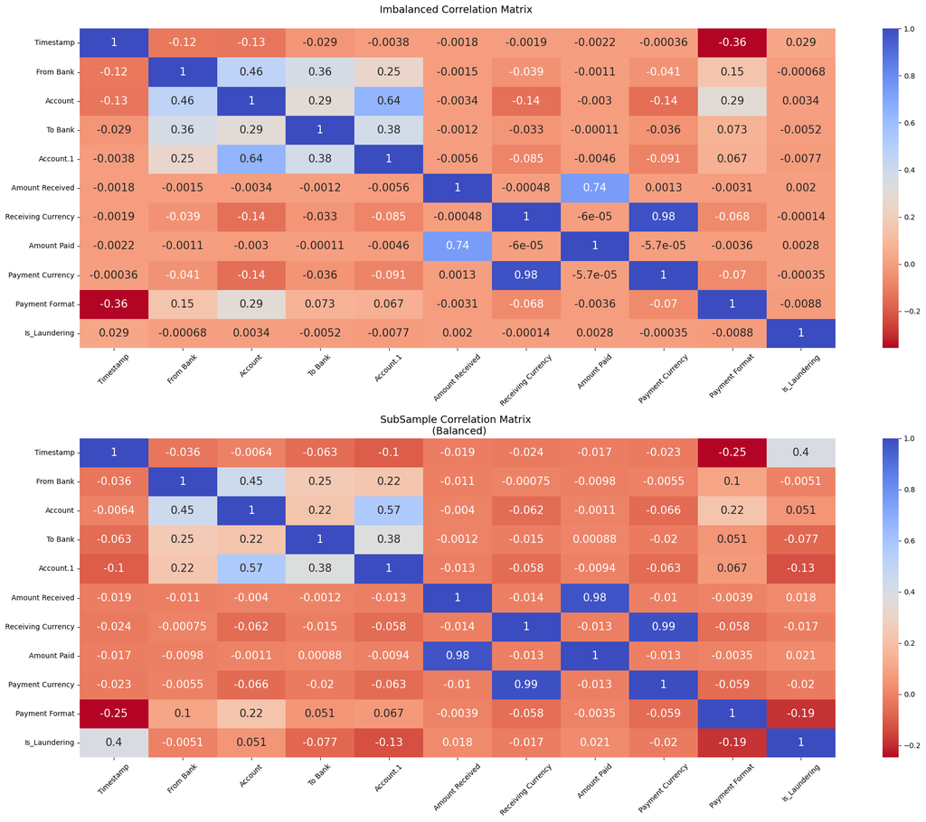

```python
f, (ax1, ax2) = plt.subplots(2, 1, figsize=(20, 16))

# Correlation matrix for the entire DataFrame
corr = df_normalized.corr()
sns.heatmap(corr, cmap='coolwarm_r', annot=True, annot_kws={'size': 15}, ax=ax1)
ax1.set_title("Imbalanced Correlation Matrix", fontsize=14)
ax1.tick_params(axis='x', labelrotation=45)  # Rotate x-axis labels

# Correlation matrix for the subsampled dataset
sub_sample_corr = new_df.corr()
sns.heatmap(sub_sample_corr, cmap='coolwarm_r', annot=True, annot_kws={'size': 15}, ax=ax2)
ax2.set_title('SubSample Correlation Matrix \n (Balanced)', fontsize=14)
ax2.tick_params(axis='x', labelrotation=45)  # Rotate x-axis labels
plt.tight_layout()
plt.show()
```

# In the head of `df_normalized`, we found that:

# - `Timestamp` is positively correlated with labels; higher values indicate a higher likelihood of Laundering.

# - `Payment Format` is negatively correlated with labels; lower values indicate a higher likelihood of Laundering.

**Use box plots to observe the distribution of the above two attributes:**

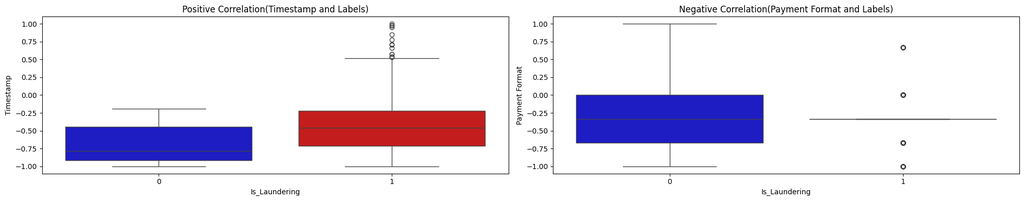

```python
f, axes = plt.subplots(ncols=2, figsize=(20,4))

sns.boxplot(x="Is_Laundering", y="Timestamp", data=new_df, palette=colors, ax=axes[0])
axes[0].set_title('Positive Correlation(Timestamp and Labels)')

sns.boxplot(x="Is_Laundering", y="Payment Format", data=new_df, palette=colors, ax=axes[1])
axes[1].set_title('Negative Correlation(Payment Format and Labels)')

plt.tight_layout()
plt.show()
```

```python
fig1 = px.scatter(new_df, x="Timestamp", y="Is_Laundering")
fig2 = px.scatter(new_df, x="Payment Format", y="Is_Laundering")
fig1.show()
fig2.show()
```

[interactive chart not shown]

In the first box plot, we can see that the median and quartiles of the `Timestamp` column are positively correlated with the values in the `Is_Laundering` column. This indicates that when the value of `Is_Laundering` is 1, the `Timestamp` values tend to be higher. This might be because money laundering transactions often involve large fund transfers, which may take longer to complete.

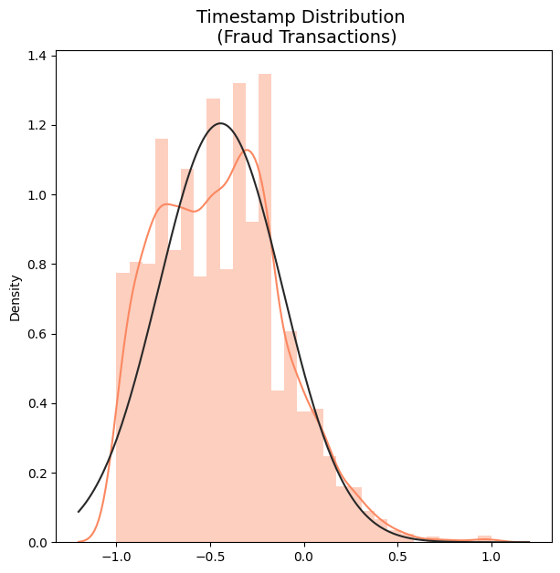

```python
from scipy.stats import norm

f, ax = plt.subplots(figsize=(7, 7))

Timestamp_fraud_dist = new_df['Timestamp'].loc[new_df['Is_Laundering'] == 1].values
sns.distplot(Timestamp_fraud_dist,ax=ax, fit=norm, color='#FB8861')
ax.set_title('Timestamp Distribution \n (Fraud Transactions)', fontsize=14)

plt.show()
```

It can be seen that the values of the `timestamp` attribute are approximately normally distributed.

**Remove outliers from the `timestamp`:**

```python
Timestamp_fraud = new_df['Timestamp'].loc[new_df['Is_Laundering'] == 1].values
q25, q75 = np.percentile(Timestamp_fraud, 25), np.percentile(Timestamp_fraud, 75)
print('Quartile 25: {} | Quartile 75: {}'.format(q25, q75))
Timestamp_iqr = q75 - q25
print('iqr: {}'.format(Timestamp_iqr))

Timestamp_cut_off = Timestamp_iqr * 1.5
Timestamp_lower, Timestamp_upper = q25 - Timestamp_cut_off, q75 + Timestamp_cut_off
print('Cut Off: {}'.format(Timestamp_cut_off))
print('Timestamp Lower: {}'.format(Timestamp_lower))
print('Timestamp Upper: {}'.format(Timestamp_upper))

outliers = [x for x in Timestamp_fraud if x < Timestamp_lower or x > Timestamp_upper]
print('Feature Timestamp Outliers for Fraud Cases: {}'.format(len(outliers)))
print('Timestamp outliers:{}'.format(outliers))

new_df = new_df.drop(new_df[(new_df['Timestamp'] > Timestamp_upper) | (new_df['Timestamp'] < Timestamp_lower)].index)

new_df.head()
```

```
Quartile 25: -0.7145854398385154 | Quartile 75: -0.22211830131448096
iqr: 0.49246713852403445
Cut Off: 0.7387007077860517
Timestamp Lower: -1.453286147624567
Timestamp Upper: 0.5165824064715707
Feature Timestamp Outliers for Fraud Cases: 14
Timestamp outliers:[0.9693629929220151, 0.5345803842265013, 0.5743174924164123, 0.8496461071786143, 0.5365015166835292, 0.9803842264914238, 0.661880687563098, 1.0, 0.5729019211321429, 0.7121334681496592, 0.5389282103133155, 0.9503538928211128, 0.7805864509605271, 0.7039433771483345]
```

|  | Timestamp | From Bank | Account | To Bank | Account.1 | Amount Received | Receiving Currency | Amount Paid | Payment Currency | Payment Format | Is_Laundering |
| --- | --- | --- | --- | --- | --- | --- | --- | --- | --- | --- | --- |
| 2183598 | -0.494540 | -0.998827 | -0.186811 | -0.295108 | -0.080056 | -1.0 | -0.571429 | -1.0 | -0.571429 | -0.333333 | 0 |
| 2937334 | -0.226390 | -0.998821 | 0.271639 | -0.999388 | 0.262285 | -1.0 | -0.714286 | -1.0 | -0.714286 | 0.000000 | 0 |
| 1630950 | -0.755106 | -0.872260 | -0.835934 | -0.999938 | -0.788610 | -1.0 | -0.428571 | -1.0 | -0.428571 | 0.000000 | 0 |
| 617751 | -0.942669 | -0.909582 | -0.605769 | 0.235399 | 0.742230 | -1.0 | 0.714286 | -1.0 | 0.714286 | -1.000000 | 0 |
| 2699362 | -0.296158 | -0.998759 | 0.741021 | -0.167045 | 0.749183 | -1.0 | 0.142857 | -1.0 | 0.142857 | -0.666667 | 0 |

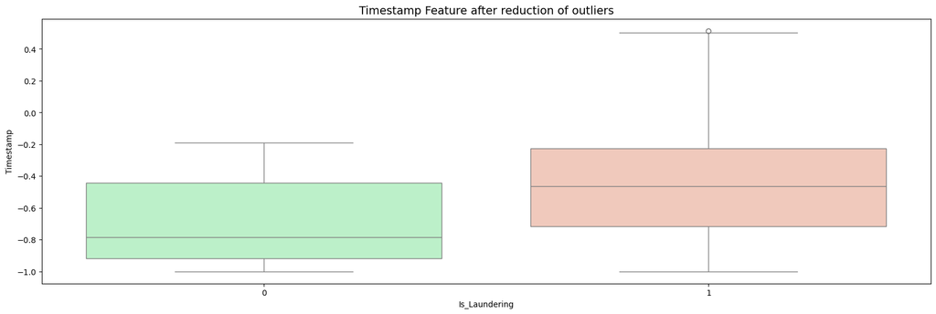

```python
f,ax1 = plt.subplots(figsize=(20,6))

colors = ['#B3F9C5', '#f9c5b3']
# Boxplots with outliers removed
# Feature V14
sns.boxplot(x="Is_Laundering", y="Timestamp", data=new_df,ax=ax1, palette=colors)
ax1.set_title("Timestamp Feature after reduction of outliers", fontsize=14)
ax1.annotate('Fewer extreme \n outliers', xy=(0.99, 0.86), xytext=(0.5, 0.25),
            arrowprops=dict(facecolor='black'),
            fontsize=14)
```

It can be seen that the outliers in `timestamp` are reduced when the label is 1.

**Train the model:**

Use the undersampled dataset, i.e., new_df, for training.

1）The `new_df` dataset is used directly for training.

```python
# Classifier Libraries
from sklearn.linear_model import LogisticRegression
from sklearn.svm import SVC
from sklearn.neighbors import KNeighborsClassifier
from sklearn.tree import DecisionTreeClassifier
from sklearn.ensemble import RandomForestClassifier

def run(data):
    # Undersampling before cross validating (prone to overfit)
    X = data.drop('Is_Laundering', axis=1)
    y = data['Is_Laundering']

    # Our data is already scaled we should split our training and test sets
    from sklearn.model_selection import train_test_split

    # This is explicitly used for undersampling.
    X_train, X_test, y_train, y_test = train_test_split(X, y, test_size=0.2, random_state=42)
    # Turn the values into an array for feeding the classification algorithms.
    X_train = X_train.values
    X_test = X_test.values
    y_train = y_train.values
    y_test = y_test.values

    # Let's implement simple classifiers
    classifiers = {
        "LogisiticRegression": LogisticRegression(),
        "KNearest": KNeighborsClassifier(),
        "Support Vector Classifier": SVC(),
        "DecisionTreeClassifier": DecisionTreeClassifier()
    }

    # Wow our scores are getting even high scores even when applying cross validation.
    from sklearn.model_selection import cross_val_score

    for key, classifier in classifiers.items():
        classifier.fit(X_train, y_train)
        training_score = cross_val_score(classifier, X_train, y_train, cv=5)
        print("Classifiers: ", classifier.__class__.__name__, "Has a training score of", round(training_score.mean(), 2) * 100, "% accuracy score")
        test_score = classifier.score(X_test, y_test)
        print("Classifiers: ", classifier.__class__.__name__, "Has a test score of", round(test_score, 2) * 100, "% accuracy score\n")
```

2）The dimensionally reduced `new_df` is used for training.

a. Use three different methods to perform dimensionality reduction on `new_df`:

```python
import time
from sklearn.manifold import TSNE
from sklearn.decomposition import PCA, TruncatedSVD

# New_df is from the random undersample data (fewer instances)
X = new_df.drop('Is_Laundering', axis=1)
y = new_df['Is_Laundering']


# T-SNE Implementation
t0 = time.time()
X_reduced_tsne = TSNE(n_components=2, random_state=42).fit_transform(X.values)
t1 = time.time()
print("T-SNE took {:.2} s".format(t1 - t0))

# PCA Implementation
t0 = time.time()
X_reduced_pca = PCA(n_components=2, random_state=42).fit_transform(X.values)
t1 = time.time()
print("PCA took {:.2} s".format(t1 - t0))

# TruncatedSVD
t0 = time.time()
X_reduced_svd = TruncatedSVD(n_components=2, algorithm='randomized', random_state=42).fit_transform(X.values)
t1 = time.time()
print("Truncated SVD took {:.2} s".format(t1 - t0))
```

```
T-SNE took 5.7e+01 s
PCA took 0.0048 s
Truncated SVD took 0.0068 s
```

b. Use a combination of t-SNE and PCA for dimensionality reduction.

```python
# New_df is from the random undersample data (fewer instances)
X = new_df.drop('Is_Laundering', axis=1)
y = new_df['Is_Laundering']


# T-SNE Implementation
t0 = time.time()
X_reduced_tsne = TSNE(n_components=2, random_state=42).fit_transform(X.values)
t1 = time.time()
print("T-SNE took {:.2} s".format(t1 - t0))

# PCA Implementation
t0 = time.time()
X_reduced_tsne_and_pca = PCA(n_components=2, random_state=42).fit_transform(X_reduced_tsne)
t1 = time.time()
print("PCA took {:.2} s".format(t1 - t0))
```

```
T-SNE took 4.5e+01 s
PCA took 0.0057 s
```

**Visualize the distribution of the dimensionality-reduced `new_df`:**

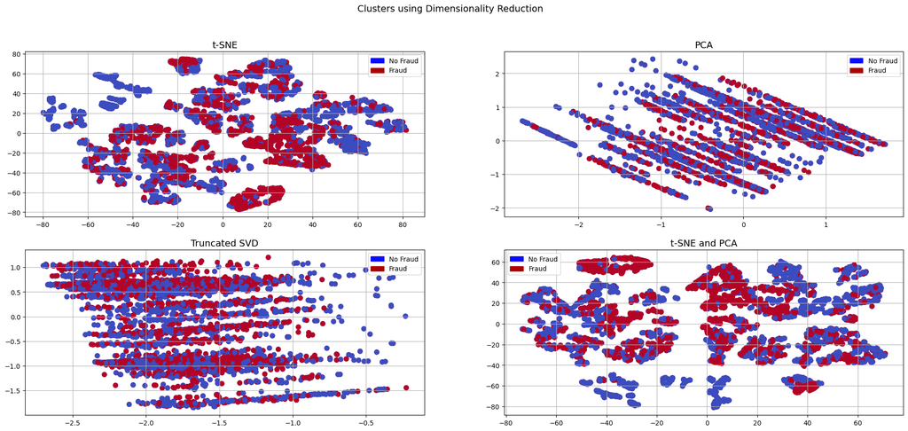

```python
import matplotlib.patches as mpatches

f, ((ax1, ax2), (ax3, ax4)) = plt.subplots(2, 2, figsize=(24,10))
# labels = ['No Fraud', 'Fraud']
f.suptitle('Clusters using Dimensionality Reduction', fontsize=14)


blue_patch = mpatches.Patch(color='#0A0AFF', label='No Fraud')
red_patch = mpatches.Patch(color='#AF0000', label='Fraud')


# t-SNE scatter plot
ax1.scatter(X_reduced_tsne[:,0], X_reduced_tsne[:,1], c=(y == 0), cmap='coolwarm', label='No Fraud', linewidths=2)
ax1.scatter(X_reduced_tsne[:,0], X_reduced_tsne[:,1], c=(y == 1), cmap='coolwarm', label='Fraud', linewidths=2)
ax1.set_title('t-SNE', fontsize=14)

ax1.grid(True)

ax1.legend(handles=[blue_patch, red_patch])


# PCA scatter plot
ax2.scatter(X_reduced_pca[:,0], X_reduced_pca[:,1], c=(y == 0), cmap='coolwarm', label='No Fraud', linewidths=2)
ax2.scatter(X_reduced_pca[:,0], X_reduced_pca[:,1], c=(y == 1), cmap='coolwarm', label='Fraud', linewidths=2)
ax2.set_title('PCA', fontsize=14)

ax2.grid(True)

ax2.legend(handles=[blue_patch, red_patch])

# TruncatedSVD scatter plot
ax3.scatter(X_reduced_svd[:,0], X_reduced_svd[:,1], c=(y == 0), cmap='coolwarm', label='No Fraud', linewidths=2)
ax3.scatter(X_reduced_svd[:,0], X_reduced_svd[:,1], c=(y == 1), cmap='coolwarm', label='Fraud', linewidths=2)
ax3.set_title('Truncated SVD', fontsize=14)

ax3.grid(True)

ax3.legend(handles=[blue_patch, red_patch])

# t-SNE and PCA
ax4.scatter(X_reduced_tsne_and_pca[:,0], X_reduced_tsne_and_pca[:,1], c=(y == 0), cmap='coolwarm', label='No Fraud', linewidths=2)
ax4.scatter(X_reduced_tsne_and_pca[:,0], X_reduced_tsne_and_pca[:,1], c=(y == 1), cmap='coolwarm', label='Fraud', linewidths=2)
ax4.set_title('t-SNE and PCA', fontsize=14)

ax4.grid(True)

ax4.legend(handles=[blue_patch, red_patch])

plt.show()
```

After visualizing the data using the dimensionality reduction methods above, it can be seen that the differences between fraudulent and non-fraudulent transactions in the dataset are not easily distinguishable.

**Proceed with the training:**

```python
run(new_df)
```

```
Classifiers:  LogisticRegression Has a training score of 68.0 % accuracy score
Classifiers:  LogisticRegression Has a test score of 70.0 % accuracy score

Classifiers:  KNeighborsClassifier Has a training score of 83.0 % accuracy score
Classifiers:  KNeighborsClassifier Has a test score of 83.0 % accuracy score

Classifiers:  SVC Has a training score of 80.0 % accuracy score
Classifiers:  SVC Has a test score of 79.0 % accuracy score

Classifiers:  DecisionTreeClassifier Has a training score of 87.0 % accuracy score
Classifiers:  DecisionTreeClassifier Has a test score of 86.0 % accuracy score
```

```python
new_df.head()
```

|  | Timestamp | From Bank | Account | To Bank | Account.1 | Amount Received | Receiving Currency | Amount Paid | Payment Currency | Payment Format | Is_Laundering |
| --- | --- | --- | --- | --- | --- | --- | --- | --- | --- | --- | --- |
| 2183598 | -0.494540 | -0.998827 | -0.186811 | -0.295108 | -0.080056 | -1.0 | -0.571429 | -1.0 | -0.571429 | -0.333333 | 0 |
| 2937334 | -0.226390 | -0.998821 | 0.271639 | -0.999388 | 0.262285 | -1.0 | -0.714286 | -1.0 | -0.714286 | 0.000000 | 0 |
| 1630950 | -0.755106 | -0.872260 | -0.835934 | -0.999938 | -0.788610 | -1.0 | -0.428571 | -1.0 | -0.428571 | 0.000000 | 0 |
| 617751 | -0.942669 | -0.909582 | -0.605769 | 0.235399 | 0.742230 | -1.0 | 0.714286 | -1.0 | 0.714286 | -1.000000 | 0 |
| 2699362 | -0.296158 | -0.998759 | 0.741021 | -0.167045 | 0.749183 | -1.0 | 0.142857 | -1.0 | 0.142857 | -0.666667 | 0 |

```
XGBoost has a test score of 89.0 % accuracy score
```

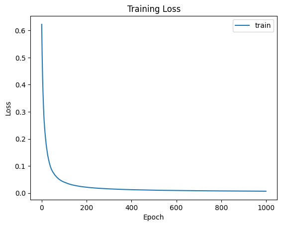

```python
import pandas as pd
import numpy as np
import xgboost as xgb
from sklearn.model_selection import train_test_split, GridSearchCV
from sklearn.metrics import accuracy_score, f1_score, recall_score, precision_score
import matplotlib.pyplot as plt

# Split the dataset into features and target variable
X = new_df.drop('Is_Laundering', axis=1)
y = new_df['Is_Laundering']

# Split the dataset into training and test sets
X_train, X_test, y_train, y_test = train_test_split(X, y, test_size=0.2, random_state=42)

# Create a DMatrix for XGBoost
dtrain = xgb.DMatrix(X_train, label=y_train)
dtest = xgb.DMatrix(X_test, label=y_test)

# Define the hyperparameters for XGBoost
params = {
    'objective': 'binary:logistic',
    'eval_metric': ['logloss', 'error'],
    'eta': 0.1,
    'max_depth': 16,
    'subsample': 0.8,
    'colsample_bytree': 0.8,
    'alpha': 0.1,
    'lambda': 1
}

# Train the XGBoost model and record the evaluation results
num_rounds = 1000
watchlist = [(dtrain, 'train'), (dtest, 'test')]
eval_results = {}
bst = xgb.train(params, dtrain, num_rounds, evals=watchlist, evals_result=eval_results)

# Evaluate the XGBoost model
y_pred = bst.predict(dtest)
y_pred = np.round(y_pred)
test_score = accuracy_score(y_test, y_pred)
print("XGBoost has a test score of", round(test_score, 2) * 100, "% accuracy score")

# Extract the training loss from the evaluation results
train_loss = eval_results['train']['logloss']

# Plot the training loss curve
plt.plot(train_loss, label='train')
plt.title('Training Loss')
plt.ylabel('Loss')
plt.xlabel('Epoch')
plt.legend()
plt.show()
```

```python
!pip install notebook
```

```
Downloading jedi-0.19.2-py2.py3-none-any.whl (1.6 MB)
   ━━━━━━━━━━━━━━━━━━━━━━━━━━━━━━━━━━━━━━━━ 1.6/1.6 MB 16.9 MB/s eta 0:00:00
```

```python
from google.colab import drive
drive.mount('/content/drive')
```

```python
!jupyter nbconvert --to html "content/drive/My Drive/Colab Notebooks/code-for-aml-xgboost.ipynb"
```

[output not shown]

[output cut: 136 more lines]

[output not shown]